# Finding Similar Board Games

Phil Henrickson

2021-12-12

## What is this analysis?

This notebook is for selecting any boardgame and identifying **its most comparable games using data from boardgamegeek.com**. I use a dimension reduction method (PCA) to learn the main points of variation in data about games from boardgamegee - this gives me a vector with every game’s value on each of the principal components. To find similar games, I compute the distance between all games using the first ten principal components. I use the distance between games to determine their overall similarity. Games that are close to each other are said to be *neighbors*.

This document details a game’s 25 nearest neighbors and illustrate some of the dimensions that make the selected game and its neighbors similar.

## Game Profile: **Harakiri: Blades of Honor**

Summary information for the selected game.

| ID | Game | Published | Player Count | Playing Time | UserRatings | Average | GeekRating | Complexity |
| --- | --- | --- | --- | --- | --- | --- | --- | --- |
| 279727 | Harakiri: Blades of Honor |  | 1-4 | 150 min | 43 | 8.92 | 5.53 | 3 |

Information on the game’s designers, artists, mechanics and categories. Note: designer and artist features are not used in identifying nearest neighbors.

| Designer(s) | Artist(s) | Categories | Mechanics |
| --- | --- | --- | --- |
| Fernando Gamero | Henning Ludvigsen | Fantasy | Action Points |
| Joel Torres | Daryl Mandryk | Exploration | Modular Board |
|  | Antonio José Manzanedo | Adventure | Variable Player Powers |
|  | Víctor Manuel Leza Moreno | Horror | Storytelling |
|  | David Demaret | Fighting | Role Playing |
|  | Joseph Diaz | Miniatures | Dice Rolling |
|  | David Benzal | Mythology | Grid Movement |
|  | Israel Pato |  |  |

For the full profile of the selected game, go to https://boardgamegeek.com/boardgame/279727

## Most Similar Games to **Harakiri: Blades of Honor**

The table below displays the most similar games to Harakiri: Blades of Honor using data from boardgamegeek (BGG). The reported similarity score is the (squared) inverse of the Manhattan distance between two games.

**Note:** The analysis does not make use of a game’s number of ratings, average, or geek average, but instead looks only at a game’s categories, mechanics, playing time, player count, and complexity. The current approach for computing the distance weighs each component equally; I plan to explore a change to this in the future by using different measures of distance, as we would reasonably expect some components to be more important than others. I initially relied on Euclidean distance, but in tinkering with the results I have opted to go with the Manhattan distance for now.

| Rank | Similarity | Published | ID | Neighbor | BGGRating | GeekRating | Complexity |
| --- | --- | --- | --- | --- | --- | --- | --- |
| 1 | 45.15 | 2014 | 146791 | Shadows of Brimstone: City of the Ancients | 7.97 | 7.00 | 3.35 |
| 2 | 40.95 | 2010 | 59946 | Dungeons & Dragons: Castle Ravenloft Board Game | 6.98 | 6.66 | 2.51 |
| 3 | 39.86 | 2014 | 150997 | Shadows of Brimstone: Swamps of Death | 8.05 | 6.85 | 3.39 |
| 4 | 38.70 | 2015 | 156548 | Super Dungeon Explore: Forgotten King | 6.93 | 6.02 | 3.14 |
| 5 | 38.04 | 2021 | 332075 | Warhammer Quest: Cursed City | 7.23 | 5.66 | 2.36 |
| 6 | 37.70 | 2011 | 91872 | Dungeons & Dragons: The Legend of Drizzt Board Game | 7.24 | 6.75 | 2.59 |
| 7 | 37.59 | 2013 | 59429 | Dark Darker Darkest | 6.29 | 5.73 | 3.28 |
| 8 | 37.17 | 2011 | 66356 | Dungeons & Dragons: Wrath of Ashardalon Board Game | 7.13 | 6.68 | 2.61 |
| 9 | 36.94 | 2019 | 299121 | Machina Arcana (Second/Third Edition) | 8.01 | 5.95 | 3.67 |
| 10 | 36.85 | 2017 | 173805 | Lobotomy | 7.26 | 5.88 | 3.46 |
| 11 | 36.83 | 2016 | 197572 | Warhammer Quest: Silver Tower | 7.49 | 6.17 | 2.35 |
| 12 | 36.71 | 2015 | 176189 | Zombicide: Black Plague | 7.67 | 7.30 | 2.51 |
| 13 | 36.65 | 2018 | 212346 | Shadows of Brimstone: Forbidden Fortress | 8.54 | 6.10 | 3.56 |
| 14 | 36.26 | 2017 | 170771 | Sword & Sorcery | 8.00 | 7.08 | 4.05 |
| 15 | 36.20 | 2017 | 197831 | Dark Souls: The Board Game | 6.53 | 6.00 | 3.15 |
| 16 | 35.81 | 2018 | 224710 | Zombicide: Green Horde | 7.76 | 6.83 | 2.52 |
| 17 | 35.63 | 2015 | 175334 | The Undercity: An Iron Kingdoms Adventure Board Game | 7.06 | 5.73 | 2.83 |
| 18 | 35.45 | 2021 | 262201 | Sword & Sorcery: Ancient Chronicles | 8.72 | 5.74 | 4.00 |
| 19 | 35.02 | 2014 | 149241 | Assault on Doomrock | 7.04 | 6.02 | 3.14 |
| 20 | 34.77 | 2017 | 159504 | Folklore: The Affliction | 7.79 | 6.47 | 3.69 |
| 21 | 34.62 | 2018 | 231618 | Deck Box Dungeons | 7.09 | 5.69 | 1.85 |
| 22 | 34.57 | 2005 | 17226 | Descent: Journeys in the Dark | 7.30 | 7.00 | 3.34 |
| 23 | 34.40 | 2015 | 172220 | Dungeons & Dragons: Temple of Elemental Evil Board Game | 7.41 | 6.39 | 2.47 |
| 24 | 34.31 | 2018 | 218395 | Sine Tempore | 7.68 | 5.72 | 3.60 |
| 25 | 34.31 | 2018 | 264198 | Warhammer Quest: Blackstone Fortress | 7.93 | 6.34 | 2.83 |

## Plotting Comparable Games to **Harakiri: Blades of Honor**

Placing the selected game and its nearest neighbors on the first two principal components.

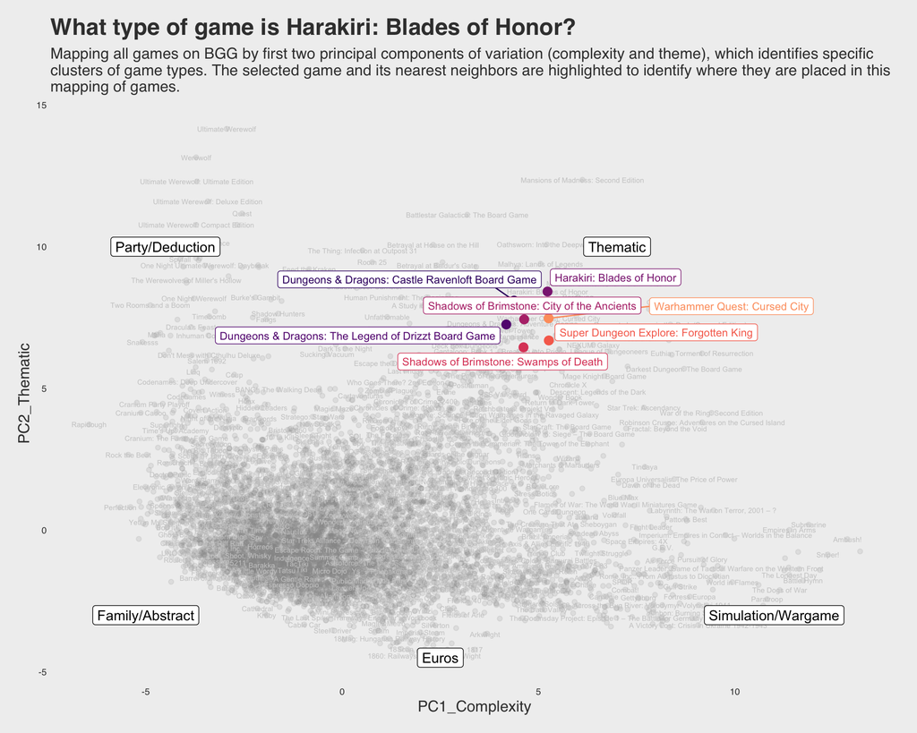

$$\\[0.05in]$$

Placing games on the first four principal components, which I have found to loosely map to complexity, theme, economy, and cooperation.

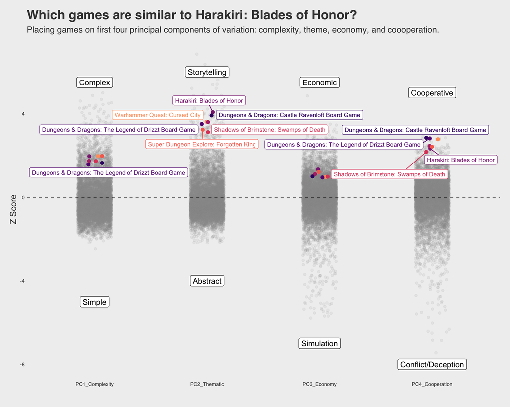

$$\\[0.05in]$$